# **Advanced data analysis demo**

## Aggregation

```r
# Aggregation of all error values per loan_officer_id (and Variant).
# Note: Since each loan officer is assigned to only one group/variant, we could also group by
#       loanofficer_id alone.
loan_data_final <- loan_data_filtered %>%
  group_by(Variant, loanofficer_id) %>%
  summarise(total_typeI_init = sum(typeI_init),
            total_typeI_fin = sum(typeI_fin),
            total_typeII_init = sum(typeII_init),
            total_typeII_fin = sum(typeII_fin),
            fully_complt = sum(fully_complt),
            .groups = "drop")
```

# Step 2: Hypothesis and OEC (Overall Evaluation Criteria) Formulation

## OEC (Overall Evaluation Criteria) Formulation

**OEC:** Percentage change in error (weighted 0.25 Type I and 0.75 Type II) between the intuitive decisions (without programme insights) and the final decision (including programme insights).

**Explanation:**

- We use the **percentage change in error (before vs. after programme insights)** as the total mean error rates (Treatment vs. Control) **before the programme insights** differ significantly (see the table below for further explanations). - These should actually be close to each other, as no different factors (such as different computer predictions) have been applied yet.
  - *Possible Problem: Extremely small sample size.*
- **Weighting 0.75 x Type II and 0.25 x Type I**, since the company is primarily conservative and wants to avoid bad loans (focus Type II), but is still interested in not missing good loans (Type I).

*Note: The best approach would be to increase the sample size, with which we could potentially simplify the OEC (e.g. by only using a weighted average of the error rates). However, since we have to use the following data to conduct our A/B-Test, we tried to eliminate the identified problems.*

```r
# Total Mean Error Rates (Treatment vs. Control) BEFORE programme insights (should be similar)
loan_data_final %>%
  mutate(total_error_rate_init = (total_typeI_init + total_typeII_init)/fully_complt) %>%
  group_by(Variant) %>%
  summarise(frequency=n(),
            mean_total_error_rate_init=mean(total_error_rate_init))
```

```
## # A tibble: 2 × 3
##   Variant   frequency mean_total_error_rate_init
##   <fct>         <int>                      <dbl>
## 1 Control          10                      0.478
## 2 Treatment        28                      0.342
```

```r
# As explained above, we observe a noticeable difference in the total mean error rates
# between the Control and Treatment group before programme insights.
# This indicates that the decision quality of the two groups was already different from the start.
#
# -> Ignoring this difference would lead to misleading conclusions when comparing errors
#    after using the new programme, as any observed significance could be driven by the
#    initial disparity in error rates rather than the programme effect itself.
#
# -> The different initial error rates are observed in the output above:
#    - Control: 47.8%
#    - Treatment: 34.2%
```

## OEC (Overall Evaluation Criteria) Creation

**OEC-Creation**

```r
# Create our OEC (See explanation above)
loan_data_final <- loan_data_final %>%
  mutate(rel_err_change = 0.25*((total_typeI_fin-total_typeI_init)/total_typeI_init) +
                          0.75*((total_typeII_fin-total_typeII_init)/total_typeII_init)) %>%
  select(-total_typeI_init, -total_typeI_fin, -total_typeII_init, -total_typeII_fin, -fully_complt)
```

**OEC-Distribution-Check and Further Data Cleaning**

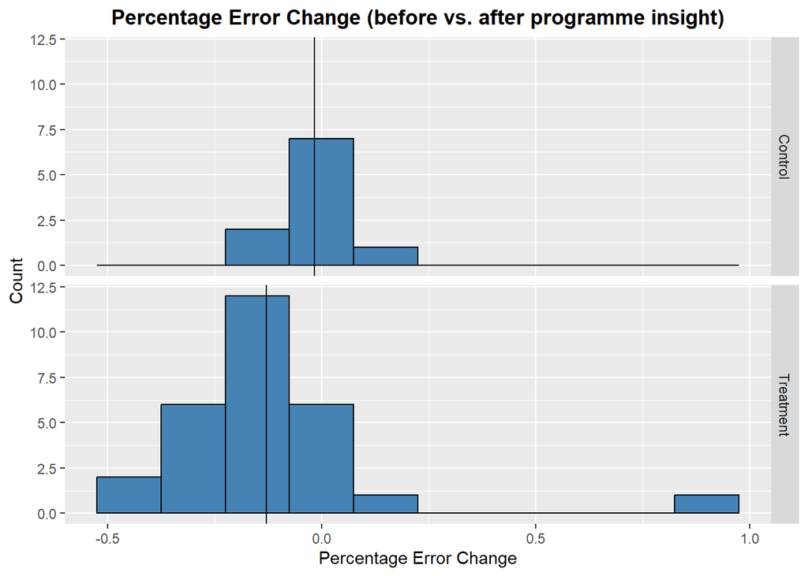

```r
# Calculte the average error change per variant
mean_rel_error_change <- loan_data_final %>%
  group_by(Variant) %>%
  summarise(frequency=n(),
            mean=mean(rel_err_change))

# Histogram of the average error change per variant
( histogram_rel_err_change_by_variant <- ggplot(loan_data_final) +
  geom_histogram(aes(x = rel_err_change), fill = "steelblue", binwidth = 0.15, color = "black") +
  geom_vline(data=mean_rel_error_change, mapping=aes(xintercept=mean), col="black") +
  facet_grid(Variant ~ .) +
  labs(x = "Percentage Error Change", y = "Count",
       title = "Percentage Error Change (before vs. after programme insight)") +
                                            theme(plot.title = element_text(hjust = 0.5,
                                                  face = "bold")) )
```

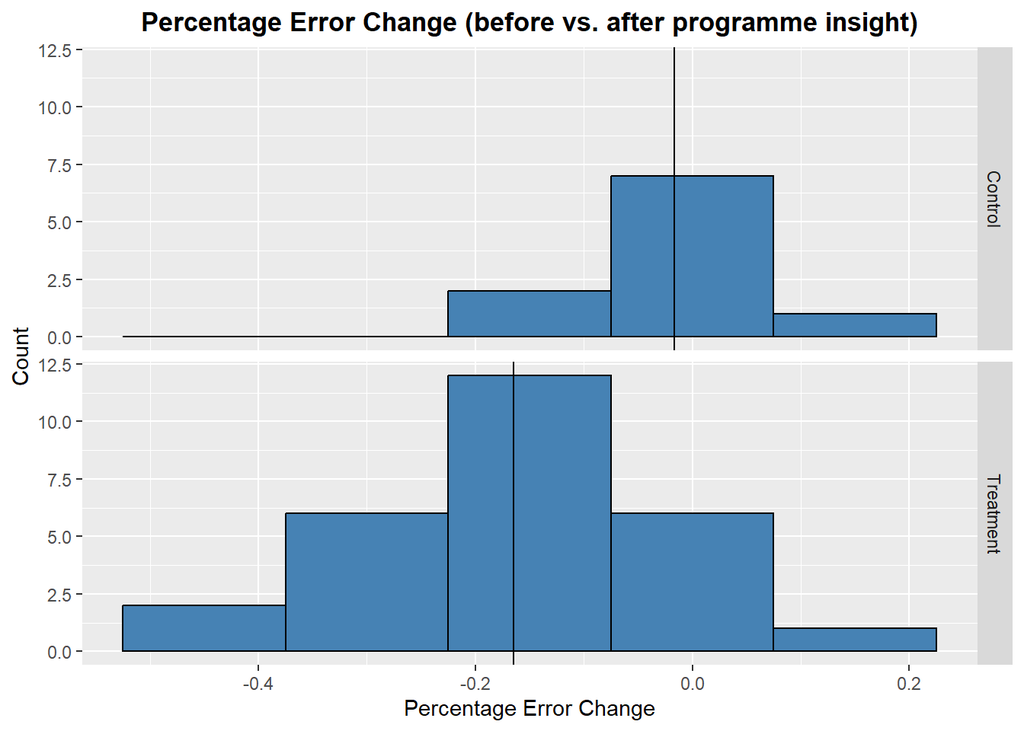

```r
# We see one outlier (9lejzokf: increase in Error: 83%)

# Explanation of the outlier and further action:
# Type I Error Change: (16 - 50) / 50 = -68%
# Type II Error Change: (7 - 3) / 3 = +133%
# Weighted Error Change: 0.25 * (-68%) + 0.75 * 133% = 83%
# -> We see a substantial increase in the weighted error, but this is mainly because the values
#    used to compute the change are quite limited due to the small sample size.
# -> Here, an increase in error from 3 to 7 immediately results in a very high percentage change of 133%.
# -> As we don’t want our analysis to be overly affected by this effect, we exclude this loan officer.

# Note again: Those steps are mainly made because we don't have a lot of data at hand.

# As described above we exclude the loan officer "9lejzokf"
loan_data_final <- loan_data_final %>%
  filter(loanofficer_id != "9lejzokf")

# Calculte the average error change per variant
mean_rel_error_change <- loan_data_final %>%
  group_by(Variant) %>%
  summarise(frequency=n(),
            mean=mean(rel_err_change))

# Histogram of the average error change per variant
( histogram_rel_err_change_by_variant <- ggplot(loan_data_final) +
  geom_histogram(aes(x = rel_err_change), fill = "steelblue", binwidth = 0.15, color = "black") +
  geom_vline(data=mean_rel_error_change, mapping=aes(xintercept=mean), col="black") +
  facet_grid(Variant ~ .) +
  labs(x = "Percentage Error Change", y = "Count",
       title = "Percentage Error Change (before vs. after programme insight)") +
                                            theme(plot.title = element_text(hjust = 0.5,
                                                  face = "bold")) )
```

**First glance at the difference between Control and Treatment**

```r
loan_data_final %>%
  group_by(Variant) %>%
  summarise(frequency=n(),
            mean=mean(rel_err_change))
```

```
## # A tibble: 2 × 3
##   Variant   frequency    mean
##   <fct>         <int>   <dbl>
## 1 Control          10 -0.0166
## 2 Treatment        27 -0.165
```

The Errors in the control group decreased by 1.66% after they saw the computer programme. Whereas the Errors in the Treatment group decreased by 16.5% after they saw the computer programme.

# Step 3: Analysis

## Welch two-sample t-tests to examine a significant difference between 2 Variants

**Check the prerequisites of a t-test:**

- Independence of Data: We checked that each loan Officer is allocated to only one Variant
- Normality of Data: Our OEC-Values are approximately normally distributed
- Continuous Data: Our OEC-Values are continuous

```r
t.test(rel_err_change ~ Variant, data = loan_data_final,
       var.equal = FALSE)
```

```
##
##  Welch Two Sample t-test
##
## data:  rel_err_change by Variant
## t = 3.8298, df = 24.379, p-value = 0.0007922
## alternative hypothesis: true difference in means between group Control and group Treatment is not equal to 0
## 95 percent confidence interval:
##  0.0683669 0.2278869
## sample estimates:
##   mean in group Control mean in group Treatment
##             -0.01664455             -0.16477146
```

```r
# With var.eual = FALSE we conduct a Welch t-test, where we assume that the samples have unequal variances
```

**Statistically significant** The mean values show us that the error in the control group, which used the old program, was reduced by 1.66%, whereas the error in the treatment group, which used the new program, was reduced by 16.48%.

The two-sample independent t-test shows that the mean error rate of the control group (-1.66%) and the treatment group (-16.48%) differ significantly, indicating that the decrease in the error rate is greater in the treatment group (t(24.38) = 3.83, p < 0.001).

## Compute Differences in OEC (Overall Evaluation Criteria) between Variants

We have examined statistical significance; now we want to assess practical significance by looking at the actual difference in OEC values and the percentage change between variants.

```r
# Compute the difference in OEC
loan_data_final %>%
  group_by(Variant) %>%
  summarise(mean_rel_err_change = mean(rel_err_change)) %>%
  summarise(Diff_Treatment_Control = mean_rel_err_change[Variant == "Treatment"] -
                                      mean_rel_err_change[Variant == "Control"])
```

```
## # A tibble: 1 × 1
##   Diff_Treatment_Control
##                    <dbl>
## 1                 -0.148
```

```r
t.test(rel_err_change ~ Variant, data = loan_data_final, var.equal = FALSE)$conf.int
```

```
## [1] 0.0683669 0.2278869
## attr(,"conf.level")
## [1] 0.95
```

The error rate of the treatment group reduced by 14.8% (CI=[6.84%, 22.79%]) more in comparison to the control group.

## Compute & Interpret Effect Size (Control vs. Treatment)

Effect size evaluates practical significance by measuring how large the difference between groups is relative to the data’s variability. - Absoulte value of 0.2 or less: small, 0.3-0.5 medium, 0.8 or bigger: large effect size

```r
Control = loan_data_final$rel_err_change[loan_data_final$Variant == "Control"]
Treatment = loan_data_final$rel_err_change[loan_data_final$Variant == "Treatment"]

cohens_d(Control, Treatment) # compute the effect size of difference between Treatment 1 and Control
```

```
## Cohen's d |       95% CI
## ------------------------
## 1.18      | [0.40, 1.95]
##
## - Estimated using pooled SD.
```

```r
effectsize::interpret_cohens_d(1.18)
```

```
## [1] "large"
## (Rules: cohen1988)
```

We can see a large effect size

# Step 4: Conclusion

## Outcome-Analysis

The two-sample independent t-test shows that the reduction in the mean error rate of the control group (-1.66%) and the treatment group (-16.48%) differ significantly, demonstrating a greater decrease in error rate by 14.8% (CI=[6.84%, 22.79%]) in the treatment group compared to the control group (t(24.38) = 3.83, p < 0.001, d = 1.18).

## Recap

When loan officers use the new prediction model in their loan review process, they can reduce their error rate to a greater extent compared to those using the old prediction model. This improvement indicates that the model is practically significant and effectively improves decision-making, resulting in more accurate loan approvals and rejections. This conclusion is supported by the conducted analysis, including the corresponding p-value and Cohen’s d measure.

## Limitations and Recommendations

All results must be interpreted with caution, as the sample size was very small, and we encountered some inconsistencies in the data. While the evaluation indicates that the new model reduces the error rate to a greater extent than the old model, this should be validated with a more robust data set. Therefore, we recommend properly recollecting the data, ensuring completeness and accuracy, and slightly expanding the sample before conducting a second, more representative test run to validate the findings above.

##———————– ADDITIONAL RESOURCES ———————–##

THE CODE ABOVE (STEPS 1-4) IS USED *AFTER* THE EXPERIMENT HAS BEEN RUN TO *ANALYZE THE DATA* HOWEVER, *BEFORE* RUNNING AN EXPERIMENT, TO *COMPUTE THE REQUIRED SAMPLE SIZE*, YOU CAN USE THE CODE BELOW:

### Compute Required Sample Size for Desired Power Level of 80% and Specific Effect Size - For 2 Variants

```r
library(pwr)
pwr.t.test(power = .8, # means 80% power, or probability of correctly rejecting the null hypothesis
           d = .5, # Cohen's d (effect size)
           sig.level = 0.05,
           type = "two.sample") # treatment vs. control
```

```
##
##      Two-sample t test power calculation
##
##               n = 63.76561
##               d = 0.5
##       sig.level = 0.05
##           power = 0.8
##     alternative = two.sided
##
## NOTE: n is number in *each* group
```

- if trying to detect bigger effect sizes (increase d Value) (e.g. in environments with less noise, or for small companies that need bigger changes), sample size requirements will decrease -> as we need less data (sample size) for detecting (true) big changes (large effects)
- if reducing significance level threshold for p-val, sample size requirement will increase
- if requiring bigger power level, sample size requirement will also increase

DS: - Power = 80% → If the new pricing truly increases revenue, we will detect this 80% of the time. - α = 5% → If the new pricing actually has no effect, we will mistakenly conclude it works 5% of the time

### Compute Required Sample Size for Desired Power Level of 80% and Specific Effect Size - For More Than 2 Variants

```r
required_sample_size <- pwr.anova.test(
  k = 3,         # Number of groups (3 variants -> control vs. t1 vs. t2)
  f = 0.05,       # Effect size (Cohen's f)
  sig.level = 0.05,  # Significance level
  power = 0.8    # Desired power
)

# Print the results
print(required_sample_size)
```

```
##
##      Balanced one-way analysis of variance power calculation
##
##               k = 3
##               n = 1285.624
##               f = 0.05
##       sig.level = 0.05
##           power = 0.8
##
## NOTE: n is number in each group
```